[GitHub Python Bar Review](https://github.com/ckorikov/python-bar-review)

# Вложенные функции, замыкания и декораторы

## 1. Функции

**Функция** — часть программы, которую можно вызвать из другого места программы.

Все в Python объекты. И даже функции. Это значит, что у функций есть

- атрибуты
- и методы.

От остальных объектов функции отличаются тем, что их можно вызвать*. Объекты, которые можно вызвать, называют `Callable`-объектами. У них есть метод `__call__()`.

* С точки зрения синтаксиса еще можно вызывать классы

### Как определить функцию

```python
# Функция определяется таким синтаксисом
def plus_one(x: int) -> int:
    """Функция возвращает увеличенное на 1 целое число"""
    return x+1
```

Это избыточное определение. Из избыточного здесь использованы:

- строка документирования — `docstring`,
- и анотация функции.

На самом деле можно описать эту же функцию компактней.

```python
# Функция plus_one без анотаций и документации
def plus_one_simple(x): return x+1
```

### Функция как объект

Как у любого объекта в python, у функции есть:

- идентификатор,
- тип.

```python
# У функции plus_one эти параметры выглядят так
id(plus_one), type(plus_one)
```

```
(140144394334992, function)
```

В CPython идентификатор — **адрес объекта** в виртуальной памяти

```python
# Идентификатор в шестнадцатиричном формате — адрес функции plus_one
hex(id(plus_one))
```

```
'0x7f75e8d77310'
```

Все атрибуты и методы функции как объекта можно посмотреть:

```python
import inspect
list(filter(lambda x: x[0] != "__globals__", sorted(inspect.getmembers(plus_one))))
# Здесь мы выбросили поле "__globals__", чтобы не засорять вывод
```

```
[('__annotations__', {'x': int, 'return': int}),
 ('__call__',
  <method-wrapper '__call__' of function object at 0x7f75e8d77310>),
 ('__class__', function),
 ('__closure__', None),
 ('__code__',
  <code object plus_one at 0x7f75e8d642f0, file "<ipython-input-1-188af9b6c882>", line 2>),
 ('__defaults__', None),
 ('__delattr__',
  <method-wrapper '__delattr__' of function object at 0x7f75e8d77310>),
 ('__dict__', {}),
 ('__dir__', <function function.__dir__()>),
 ('__doc__', 'Функция возвращает увеличенное на 1 целое число'),
 ('__eq__', <method-wrapper '__eq__' of function object at 0x7f75e8d77310>),
 ('__format__', <function function.__format__(format_spec, /)>),
 ('__ge__', <method-wrapper '__ge__' of function object at 0x7f75e8d77310>),
 ('__get__', <method-wrapper '__get__' of function object at 0x7f75e8d77310>),
 ('__getattribute__',
  <method-wrapper '__getattribute__' of function object at 0x7f75e8d77310>),
 ('__gt__', <method-wrapper '__gt__' of function object at 0x7f75e8d77310>),
 ('__hash__',
  <method-wrapper '__hash__' of function object at 0x7f75e8d77310>),
 ('__init__',
  <method-wrapper '__init__' of function object at 0x7f75e8d77310>),
 ('__init_subclass__', <function function.__init_subclass__>),
 ('__kwdefaults__', None),
 ('__le__', <method-wrapper '__le__' of function object at 0x7f75e8d77310>),
 ('__lt__', <method-wrapper '__lt__' of function object at 0x7f75e8d77310>),
 ('__module__', '__main__'),
 ('__name__', 'plus_one'),
 ('__ne__', <method-wrapper '__ne__' of function object at 0x7f75e8d77310>),
 ('__new__', <function function.__new__(*args, **kwargs)>),
 ('__qualname__', 'plus_one'),
 ('__reduce__', <function function.__reduce__()>),
 ('__reduce_ex__', <function function.__reduce_ex__(protocol, /)>),
 ('__repr__',
  <method-wrapper '__repr__' of function object at 0x7f75e8d77310>),
 ('__setattr__',
  <method-wrapper '__setattr__' of function object at 0x7f75e8d77310>),
 ('__sizeof__', <function function.__sizeof__()>),
 ('__str__', <method-wrapper '__str__' of function object at 0x7f75e8d77310>),
 ('__subclasshook__', <function function.__subclasshook__>)]
```

### Как вызвать функцию

```python
#  Вызов функции, ожидаем ответ 2
plus_one(1)
```

```
2
```

```python
#  Можно явно вызвать метод call, ожидаем ответ 2
plus_one.__call__(1)
```

```
2
```

### Как функции устроены

```python
# Байт-код функции function_name
plus_one.__code__.co_code
```

```
b'|\x00d\x01\x17\x00S\x00'
```

```python
# Дизассемблированное тело функции function_name
import dis
dis.dis(plus_one)
```

```
  4           0 LOAD_FAST                0 (x)
              2 LOAD_CONST               1 (1)
              4 BINARY_ADD
              6 RETURN_VALUE
```

Если заглянуть во внутренности интерпретатора (CPython), то функция описывается следующей струтурой: https://github.com/python/cpython/blob/3.7/Include/funcobject.h

### Почитать

1. [The Python Language Reference. Data model](https://docs.python.org/3/reference/datamodel.html#objects-values-and-types)
2. [The Python Language Reference. Inspect live objects](https://docs.python.org/3/library/inspect.html)
3. [PEP 3107 -- Function Annotations](https://www.python.org/dev/peps/pep-3107/)
4. [PEP 257 -- Docstring Conventions](https://www.python.org/dev/peps/pep-0257/)

## 2. Вложенные функции

**Вложенная функция** — функция, которая определена внутри другой функции.

При работе с вложенными функциями надо учитывать области видимости.

### Область видимости в Python — LEGB

В Python есть 4 области видимости. Расположены они как показано на рисунке.

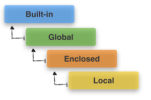

Стрелки на рисунке показывают в какой последовательности Python обходит области видимости. Следующий код показывает как распределены области относительно вложенной функции inner.

```python
# (built-in) — область системных имен

# global — область модуля
def outer():
    # enclosed — область функции-обёртки
    def inner():
        # local — область внутри функции
        pass
```

### Зачем нужны вложенные функции?

Зачем это может быть нужно? Можно выделить 3 примера:

1. чтобы скрыть функцию в глобальной области видимости,
2. чтобы вынести «лишний» код из функцию в обёртку,
3. чтобы реализовать замыкания (см. следующий раздел).

#### Пример 1. Чтобы скрыть функцию — инкапсуляция

```python
# Вложенная функция inner внутри plus_one_outer
def plus_one_outer(x):
    """Функция возвращает увеличенное на 1 целое число"""
    def inner(y): return y+1
    return inner(x)
```

```python
#  Вызов функции, ожидаем ответ 2
plus_one_outer(1)
```

```
2
```

```python
# Вложенная функция недоступна (должна быть ошибка)
inner(1)
```

```
---------------------------------------------------------------------------
NameError                                 Traceback (most recent call last)
<ipython-input-13-9439a6ed8a3c> in <module>
      1 # Вложенная функция недоступна (должна быть ошибка)
----> 2 inner(1)

NameError: name 'inner' is not defined
```

Вложенные функции дают накладные расходы

```python
import dis
dis.dis(plus_one_outer)
```

```
  4           0 LOAD_CONST               1 (<code object inner at 0x7f75e851fc90, file "<ipython-input-11-c887b5072665>", line 4>)
              2 LOAD_CONST               2 ('plus_one_outer.<locals>.inner')
              4 MAKE_FUNCTION            0
              6 STORE_FAST               1 (inner)

  5           8 LOAD_FAST                1 (inner)
             10 LOAD_FAST                0 (x)
             12 CALL_FUNCTION            1
             14 RETURN_VALUE

Disassembly of <code object inner at 0x7f75e851fc90, file "<ipython-input-11-c887b5072665>", line 4>:
  4           0 LOAD_FAST                0 (y)
              2 LOAD_CONST               1 (1)
              4 BINARY_ADD
              6 RETURN_VALUE
```

#### Пример 2. Чтобы вынести «лишний» код из функции в обёртку

```python
def factorial(x):
    """Функция вычисляет факториал целого числа"""
    def calc_factorial(y): return y * calc_factorial(y-1) if y!=0 else 1
    if x<0:
        return -1
    return calc_factorial(x)
```

```python
factorial(4)
```

```
24
```

## 3. Замыкания

**Замыкание** — вложенная функция, которая запоминает значения окружения, с которым она была вызвана. Говорят, что функция «замыкается» на значения переменных окружения. По сути это техника параметризированной генерации функций.

Рассмотрим простой пример замыкания

```python
# Функция-обёртка принимает возвращает внутренную функцию, которая «замкнута» на значение a
def gen_mul(a):
    def inner(b):
        return a*b
    return inner
```

```python
# gen_mul возвращает функцию, которая будет всегда умножать на 2
double = gen_mul(2)
```

```python
# Проверим (должно быть 6)
double(3)
```

```
6
```

```python
# Можно возвращаемую функцию не сохранять
gen_mul(2)(3)
```

```
6
```

Функции, которые возвращают другие функции, называются **«фабриками функций»**.

#### Проблема late binding

В замыканиях все переменные внутри вложенной функции вычисляются в момент её вызова, а не создания. Это называется позднее связывание (англ. [late binding](https://en.wikipedia.org/wiki/Late_binding)). Из-за него могут возникнуть проблемы, как в примере ниже.

```python
# Проблема с late binding
powers = []
for i in (1,2):
    def inner(x):
        return x**i
    powers.append(inner)

# Хотим получить список степеней 5-ки
for p in powers:
    print(p(5))
```

```
25
25
```

Вместо ожидаемых двух степеней 5-ки получи два раза возведение в последнюю степень из списка. Это происходит из-за того, что в момент вызова `p(5)` в теле функции переменная i «смотрит» на последнее своё значение, т. е. 2.

Это можно исправить, если создавать копии `i` при создании замыканий. Это можно сделать с помощью обёртки. При каждом вызове функции параметры указывают на значения аргументов функции. Поэтому замыкания «замыкаются» на текущие значения счётчика.

```python
# Решение проблемы late binding через обёртку (здесь make_inner)
powers = []
for i in (1,2):
    def make_inner(j):
        def inner(x):
            return x**j
        return inner
    powers.append(make_inner(i))

for p in powers:
    print(p(5))
```

```
5
25
```

Другое решение — использовать тот факт, что значения параметров по-умолчанию вычисляются при создании функции.

```python
# Решение проблемы late binding через стандарное знаечение аргумента функции
powers = []
for i in (1,2):
    def inner(x, i=i):
        return x**i
    powers.append(inner)

for p in powers:
    print(p(5))
```

```
5
25
```

## 4. Декораторы

**Декоратор** — «синтаксический сахар» для функции-обёртки вокруг другой функции. Обычно декоратор используют, чтобы добавить новое поведение другой функции без изменения ее тела.

```python
# Возьмем простую функцию возведения в квадрат
def sqr(x): return x*x
sqr(5)
```

```
25
```

### Пример элементарного декоратора

Мы хотим обёрнуть функцию возведения в квадрат другой функцией, чтобы добавить новые возможности. Ниже приведен пример фабрики функций, которая возвращает функцию-обёртку. Эта функция-обёртка выполняет новый код и вызывает оборачивемую функцию.

```python
from time import perf_counter_ns

# Фабрика функций, которая генерирует обернутые функции func для отладки вызова и результата
def make_debugable(func):
    def wrapper(x):
        print(f"[DEBUG] Launch function {func} with x={x}")
        start_time_ns = perf_counter_ns()
        result = func(x)
        stop_time_ns = perf_counter_ns()
        duration_ns = stop_time_ns-start_time_ns
        print(f"[DEBUG] Time: {duration_ns}ns")
        return result
    return wrapper
```

Обернём функцию sqr, сгенерированное значение будем хранить в sqrt2.

```python
sqrt2 = make_debugable(sqr)
sqrt2(5)
```

```
[DEBUG] Launch function <function sqr at 0x7f75e84a69d0> with x=5
[DEBUG] Time: 11200ns
```

```
25
```

Синтаксический сахар декораторов позволяет описать такое поведение короче. При этом декоратор генерирует обёрнутую функцию с таким же именем как у обораичиваемой.

```python
# Следующий код эквивалентен: sqr3 = make_debugable(sqr3)
@make_debugable
def sqr3(x): return x*x

sqr3(4)
```

```
[DEBUG] Launch function <function sqr3 at 0x7f75e8539820> with x=4
[DEBUG] Time: 12900ns
```

```
16
```

#### Практичный пример применения декоратора `make_debugable`

Сравним скорость работы встроенной функции `sum` с написанной «руками» с помощью декоратора `make_debugable`.

```python
@make_debugable
def sum_1(n):
    """Суммирование чисел от 1 до n в цикле for"""
    s = 0
    for i in range(n):
        s += i
    return s
```

```python
@make_debugable
def sum_2(n):
    """Суммирование чисел от 1 до n встроенной функцией"""
    return sum(range(n))
```

```python
sum_1(10000)
```

```
[DEBUG] Launch function <function sum_1 at 0x7f75e85399d0> with x=10000
[DEBUG] Time: 1849400ns
```

```
49995000
```

```python
sum_2(10000)
```

```
[DEBUG] Launch function <function sum_2 at 0x7f75e844b310> with x=10000
[DEBUG] Time: 437100ns
```

```
49995000
```

Наглядно видно, что встроенная функция производительней.

### Пример рабочего декоратора

По сути декоратор возвращает другую функцию. Если проверить документацию к функции:

```python
# Проверка справки (не должен вернуть строку)
help(sum_1)
```

```
Help on function wrapper in module __main__:

wrapper(x)
```

Чтобы возвращаемая функция была похожа на оборачиваемую надо скопировать внутренние атрибуты.

```python
from functools import wraps
from time import perf_counter_ns

# Улучшенная фабрика функций, которая генерирует обернутые функции func для отладки вызова и результата
def make_debugable_real(func):
    @wraps(func) # Декоратор из библиотеки для копирования внутренних атрибутов
    def wrapper(x):
        print(f"[DEBUG] Launch function {func} with x={x}")
        start_time_ns = perf_counter_ns()
        result = func(x)
        stop_time_ns = perf_counter_ns()
        duration_ns = stop_time_ns-start_time_ns
        print(f"[DEBUG] Time: {duration_ns}ns")
        return result
    return wrapper
```

```python
@make_debugable_real
def sum_3(n):
    """Суммирование чисел от 1 до n встроенной функцией"""
    return sum(range(n))
```

```python
# Проверка справки (теперь должен вернуть строку)
help(sum_3)
```

```
Help on function sum_3 in module __main__:

sum_3(n)
    Суммирование чисел от 1 до n встроенной функцией
```

### Пример рабочего декоратора с параметрами

Чтобы декоратор принимал аргументы, надо сформировать замыкание фабрики обёрток с параметром декоратора.

```python
from functools import wraps

# Фабрика генераторов функций, которая позволяет использовать параметры, функция умножает результат функции на число.
def mul(p):
    def decorator(func):
        @wraps(func)
        def wrapper(*args): # Упаковали параметры (см. ниже)
            return p*func(*args) # Распаковали параметры обратно (см. ниже)
        return wrapper
    return decorator
```

Объявим функцию с двумя декораторами. Декораторы применяются последовательнос снизу вверх.

```python
@mul(2)
@mul(4)
def f(x: int, y: int):
    return x+y
```

```python
# Должно быть 24 так как 2(4(1+2)) = 24
f(1,2)
```

```
24
```

#### Упаковка и распаковка параметров

При работе с последовательностями можно собирать значения в переменные. Это называется **упаковка**. Синтаксис такой.

```python
a, *b, c = [2, 7, 5, 6, 3, 4, 1]
```

В `b` теперь список всего того, что не попало в `a` и `c`

```python
print(b)
```

```
[7, 5, 6, 3, 4]
```

Эти значения можно подставить используя **распаковку**.

```python
print(*b)
```

```
7 5 6 3 4
```

Результат вывода разный. В первом случае вызов эквивалентен `print([b1, b2, b3])`, во втором — `print(b1, b2, b3)`.

**NB!** Упаковка и распоковка доступна и для словарей. Для этого используется **.

## Watermark

```python
%load_ext watermark
%watermark -d -u -v -iv
```

```
last updated: 2019-10-21

CPython 3.8.0
IPython 7.8.0
```